# Titanic Project.

Musa R. Nyakerabachi

2020-07-28

# Titanic: Machine Learning from Disaster Project

## Part 1:Exploratory Data Analysis.

## 1. BUSINESS UNDERSTANDING.

Source:[Machine Learning Titanic Competition](https://www.kaggle.com/c/titanic/)

Data: [Titanic Data Set from Kaggle](https://www.kaggle.com/c/titanic/data)

### Context:

Source: [Discussion](https://www.kaggle.com/c/titanic/discussion)

### Problem statement :

Using machine learning to create a model that predicts which passengers survived the Titanic shipwreck.

## 2.1 Data Description :

[output not shown]

**First I’ll load the data file using user input option `file.choose()`.The data is given in two set both training and test set.**

```r
df_train <- read.csv (file.choose(), stringsAsFactors = F,na.strings=c("","NA"," "))
df_test <- read.csv (file.choose(), stringsAsFactors = F,na.strings=c("","NA"," "))
```

**Next I’ll load the training set and test set data using `DT` package as shown below.I’ll view only the first eight columns for easy page view but if you need whole columns for the two data sets remove `[,1:8]` from the code snippet below**

```r
library(tidyverse)

DT::datatable(df_train[,1:8])
```

|  | PassengerId | Survived | Pclass | Name | Sex | Age | SibSp | Parch |
| --- | --- | --- | --- | --- | --- | --- | --- | --- |
| 1 | 1 | 0 | 3 | Braund, Mr. Owen Harris | male | 22 | 1 | 0 |
| 2 | 2 | 1 | 1 | Cumings, Mrs. John Bradley (Florence Briggs Thayer) | female | 38 | 1 | 0 |
| 3 | 3 | 1 | 3 | Heikkinen, Miss. Laina | female | 26 | 0 | 0 |
| 4 | 4 | 1 | 1 | Futrelle, Mrs. Jacques Heath (Lily May Peel) | female | 35 | 1 | 0 |
| 5 | 5 | 0 | 3 | Allen, Mr. William Henry | male | 35 | 0 | 0 |
| 6 | 6 | 0 | 3 | Moran, Mr. James | male |  | 0 | 0 |
| 7 | 7 | 0 | 1 | McCarthy, Mr. Timothy J | male | 54 | 0 | 0 |
| 8 | 8 | 0 | 3 | Palsson, Master. Gosta Leonard | male | 2 | 3 | 1 |
| 9 | 9 | 1 | 3 | Johnson, Mrs. Oscar W (Elisabeth Vilhelmina Berg) | female | 27 | 0 | 2 |
| 10 | 10 | 1 | 2 | Nasser, Mrs. Nicholas (Adele Achem) | female | 14 | 1 | 0 |

[output cut: 881 more lines]

```r
DT::datatable(df_test[,1:8])
```

|  | PassengerId | Pclass | Name | Sex | Age | SibSp | Parch | Ticket |
| --- | --- | --- | --- | --- | --- | --- | --- | --- |
| 1 | 892 | 3 | Kelly, Mr. James | male | 34.5 | 0 | 0 | 330911 |
| 2 | 893 | 3 | Wilkes, Mrs. James (Ellen Needs) | female | 47 | 1 | 0 | 363272 |
| 3 | 894 | 2 | Myles, Mr. Thomas Francis | male | 62 | 0 | 0 | 240276 |
| 4 | 895 | 3 | Wirz, Mr. Albert | male | 27 | 0 | 0 | 315154 |
| 5 | 896 | 3 | Hirvonen, Mrs. Alexander (Helga E Lindqvist) | female | 22 | 1 | 1 | 3101298 |
| 6 | 897 | 3 | Svensson, Mr. Johan Cervin | male | 14 | 0 | 0 | 7538 |
| 7 | 898 | 3 | Connolly, Miss. Kate | female | 30 | 0 | 0 | 330972 |
| 8 | 899 | 2 | Caldwell, Mr. Albert Francis | male | 26 | 1 | 1 | 248738 |
| 9 | 900 | 3 | Abrahim, Mrs. Joseph (Sophie Halaut Easu) | female | 18 | 0 | 0 | 2657 |
| 10 | 901 | 3 | Davies, Mr. John Samuel | male | 21 | 2 | 0 | A/4 48871 |

[output cut: 408 more lines]

**From above it is vividly true that training set has 891 entries white test set data has 418 entries.** **Next is a code snippet checking the summary of both train and test data given from `kaggle`.**

```r
summary(df_train)
```

```
##   PassengerId       Survived          Pclass          Name
##  Min.   :  1.0   Min.   :0.0000   Min.   :1.000   Length:891
##  1st Qu.:223.5   1st Qu.:0.0000   1st Qu.:2.000   Class :character
##  Median :446.0   Median :0.0000   Median :3.000   Mode  :character
##  Mean   :446.0   Mean   :0.3838   Mean   :2.309
##  3rd Qu.:668.5   3rd Qu.:1.0000   3rd Qu.:3.000
##  Max.   :891.0   Max.   :1.0000   Max.   :3.000
##
##      Sex                 Age            SibSp           Parch
##  Length:891         Min.   : 0.42   Min.   :0.000   Min.   :0.0000
##  Class :character   1st Qu.:20.12   1st Qu.:0.000   1st Qu.:0.0000
##  Mode  :character   Median :28.00   Median :0.000   Median :0.0000
##                     Mean   :29.70   Mean   :0.523   Mean   :0.3816
##                     3rd Qu.:38.00   3rd Qu.:1.000   3rd Qu.:0.0000
##                     Max.   :80.00   Max.   :8.000   Max.   :6.0000
##                     NA's   :177
##     Ticket               Fare           Cabin             Embarked
##  Length:891         Min.   :  0.00   Length:891         Length:891
##  Class :character   1st Qu.:  7.91   Class :character   Class :character
##  Mode  :character   Median : 14.45   Mode  :character   Mode  :character
##                     Mean   : 32.20
##                     3rd Qu.: 31.00
##                     Max.   :512.33
##
```

**From above summary it is evident that training set data average age that was in titanic was 30 while the average fare that was being paid was 32 U.S Dollar.**

```r
summary(df_test)
```

```
##   PassengerId         Pclass          Name               Sex
##  Min.   : 892.0   Min.   :1.000   Length:418         Length:418
##  1st Qu.: 996.2   1st Qu.:1.000   Class :character   Class :character
##  Median :1100.5   Median :3.000   Mode  :character   Mode  :character
##  Mean   :1100.5   Mean   :2.266
##  3rd Qu.:1204.8   3rd Qu.:3.000
##  Max.   :1309.0   Max.   :3.000
##
##       Age            SibSp            Parch           Ticket
##  Min.   : 0.17   Min.   :0.0000   Min.   :0.0000   Length:418
##  1st Qu.:21.00   1st Qu.:0.0000   1st Qu.:0.0000   Class :character
##  Median :27.00   Median :0.0000   Median :0.0000   Mode  :character
##  Mean   :30.27   Mean   :0.4474   Mean   :0.3923
##  3rd Qu.:39.00   3rd Qu.:1.0000   3rd Qu.:0.0000
##  Max.   :76.00   Max.   :8.0000   Max.   :9.0000
##  NA's   :86
##       Fare            Cabin             Embarked
##  Min.   :  0.000   Length:418         Length:418
##  1st Qu.:  7.896   Class :character   Class :character
##  Median : 14.454   Mode  :character   Mode  :character
##  Mean   : 35.627
##  3rd Qu.: 31.500
##  Max.   :512.329
##  NA's   :1
```

**From above summary it is evident that test set data average age that was in titanic was 30 while the average fare that was being paid was 36 U.S Dollar.** **Next I’ll create a table that I’ll use in presenting my result in the Kaggle competion with only two columns `Survived` and `PassengersId`**.

```r
df_test$Survived <- 0
df_new <- data.frame(PassengerId = df_test$PassengerId, Survived = df_test$Survived)
```

**Next is to see if the number of rows of the table created corresponds with the test data rows given from `Kaggle`**.

```r
nrow(df_new)
```

```
## [1] 418
```

**From the function `nrow` 418 rows have been seen which corresponds with what the `Kaggle` test set entries shows.** **Next I’ll store the table created above in a csv file using `write.csv` function but it has only 0 entries in the Survived columns which I’ll fix in the coming code snippet**.

```r
write.csv(df_new, file = "Predictor.csv", row.names = FALSE)
```

**The code shown below is to create a table where 1 represent female and 0 represent male and have two columns with `PassengerId` column and `Survived` column with `Survived` column showing 1 for female and 0 for male survival rate for two genders.**

```r
df_test$Survived [df_test$Sex == "female"] <- 1

df_new <- data.frame(PassengerId = df_test$PassengerId, Survived = df_test$Survived)
```

```r
nrow(df_new)
```

```
## [1] 418
```

**From above `nrow` function it evident that the number of rows corresponds with what is given in `Kaggle` test set data.** **Next I’ll store the result the same as what `Kaggle` competition expect the result to be presented in their titanic competition portal.**

```r
write.csv(df_new, file = "Gender_Model.csv", row.names = FALSE)
```

**Now that I have presented my prediction to the `Kaggle` competion it’s time to combine both data set for full analysis purposes using `rbind` function shown below.**

```r
df_concat <- rbind(df_train,df_test)
```

**I’ll quickly check the summary of my combined data set using `summary` function shown below and remove some judgement from it.**

```r
summary(df_concat)
```

```
##   PassengerId      Survived          Pclass          Name
##  Min.   :   1   Min.   :0.0000   Min.   :1.000   Length:1309
##  1st Qu.: 328   1st Qu.:0.0000   1st Qu.:2.000   Class :character
##  Median : 655   Median :0.0000   Median :3.000   Mode  :character
##  Mean   : 655   Mean   :0.3774   Mean   :2.295
##  3rd Qu.: 982   3rd Qu.:1.0000   3rd Qu.:3.000
##  Max.   :1309   Max.   :1.0000   Max.   :3.000
##
##      Sex                 Age            SibSp            Parch
##  Length:1309        Min.   : 0.17   Min.   :0.0000   Min.   :0.000
##  Class :character   1st Qu.:21.00   1st Qu.:0.0000   1st Qu.:0.000
##  Mode  :character   Median :28.00   Median :0.0000   Median :0.000
##                     Mean   :29.88   Mean   :0.4989   Mean   :0.385
##                     3rd Qu.:39.00   3rd Qu.:1.0000   3rd Qu.:0.000
##                     Max.   :80.00   Max.   :8.0000   Max.   :9.000
##                     NA's   :263
##     Ticket               Fare            Cabin             Embarked
##  Length:1309        Min.   :  0.000   Length:1309        Length:1309
##  Class :character   1st Qu.:  7.896   Class :character   Class :character
##  Mode  :character   Median : 14.454   Mode  :character   Mode  :character
##                     Mean   : 33.295
##                     3rd Qu.: 31.275
##                     Max.   :512.329
##                     NA's   :1
```

**From above it is like the fare did not change from above two data set and also fare.** **Next I’ll create a table to see the number of people who died and who survived.**

```r
table(df_concat$Survived)
```

```
##
##   0   1
## 815 494
```

**From the table above it is like the number of people who died are more than who survived but the proportion is not yet realised I’ll used `prop.table` function to find proportionality of the death and survival rate.**

```r
prop.table(table(df_concat$Survived))
```

```
##
##         0         1
## 0.6226127 0.3773873
```

**From above table is evident that 62% of the people in the titanic died while 38% survived.** **Next I’ll see the structure of the data using `str` function as shown below.**

```r
str(df_concat)
```

```
## 'data.frame':    1309 obs. of  12 variables:
##  $ PassengerId: int  1 2 3 4 5 6 7 8 9 10 ...
##  $ Survived   : num  0 1 1 1 0 0 0 0 1 1 ...
##  $ Pclass     : int  3 1 3 1 3 3 1 3 3 2 ...
##  $ Name       : chr  "Braund, Mr. Owen Harris" "Cumings, Mrs. John Bradley (Florence Briggs Thayer)" "Heikkinen, Miss. Laina" "Futrelle, Mrs. Jacques Heath (Lily May Peel)" ...
##  $ Sex        : chr  "male" "female" "female" "female" ...
##  $ Age        : num  22 38 26 35 35 NA 54 2 27 14 ...
##  $ SibSp      : int  1 1 0 1 0 0 0 3 0 1 ...
##  $ Parch      : int  0 0 0 0 0 0 0 1 2 0 ...
##  $ Ticket     : chr  "A/5 21171" "PC 17599" "STON/O2. 3101282" "113803" ...
##  $ Fare       : num  7.25 71.28 7.92 53.1 8.05 ...
##  $ Cabin      : chr  NA "C85" NA "C123" ...
##  $ Embarked   : chr  "S" "C" "S" "S" ...
```

**From above `Pclass` column is treated as an `int` which is not the case I’ll have to convert it into a factor of the three classes as shown below.**

```r
df_concat$Pclass = as.factor(df_concat$Pclass)
```

**Next I’ll make some inference to see if it has changes using the same `str` function as shown below.**

```r
str(df_concat)
```

```
## 'data.frame':    1309 obs. of  12 variables:
##  $ PassengerId: int  1 2 3 4 5 6 7 8 9 10 ...
##  $ Survived   : num  0 1 1 1 0 0 0 0 1 1 ...
##  $ Pclass     : Factor w/ 3 levels "1","2","3": 3 1 3 1 3 3 1 3 3 2 ...
##  $ Name       : chr  "Braund, Mr. Owen Harris" "Cumings, Mrs. John Bradley (Florence Briggs Thayer)" "Heikkinen, Miss. Laina" "Futrelle, Mrs. Jacques Heath (Lily May Peel)" ...
##  $ Sex        : chr  "male" "female" "female" "female" ...
##  $ Age        : num  22 38 26 35 35 NA 54 2 27 14 ...
##  $ SibSp      : int  1 1 0 1 0 0 0 3 0 1 ...
##  $ Parch      : int  0 0 0 0 0 0 0 1 2 0 ...
##  $ Ticket     : chr  "A/5 21171" "PC 17599" "STON/O2. 3101282" "113803" ...
##  $ Fare       : num  7.25 71.28 7.92 53.1 8.05 ...
##  $ Cabin      : chr  NA "C85" NA "C123" ...
##  $ Embarked   : chr  "S" "C" "S" "S" ...
```

**Bingo!! `Pclass` has changed to factor with three levels i.e first class, second class and third class.** **Next is to see the columns that have missing data and do some imputation to them using `sapply` function.**

```r
sapply(df_concat, function(df)
{
  sum(is.na(df)==T)/length(df)
})
```

```
##  PassengerId     Survived       Pclass         Name          Sex          Age
## 0.0000000000 0.0000000000 0.0000000000 0.0000000000 0.0000000000 0.2009167303
##        SibSp        Parch       Ticket         Fare        Cabin     Embarked
## 0.0000000000 0.0000000000 0.0000000000 0.0007639419 0.7746371276 0.0015278839
```

**From above function `Age`, `Fare`,`Cabin` and `Embarked` columns have missing values.I’ll also use `Amelia` package from Amelia who is my favorite female follower in twitter to see how missing data is distributed.**

```r
library("Amelia")
```

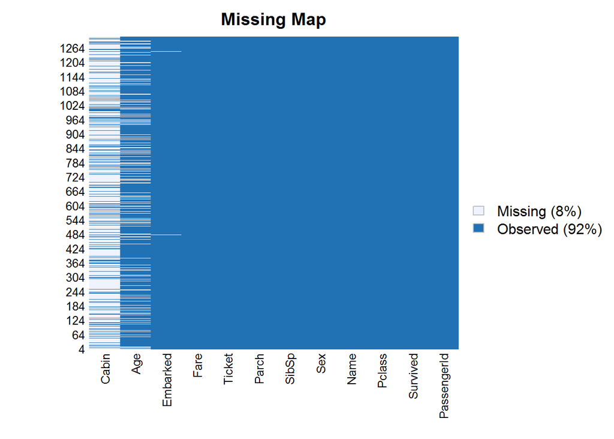

```r
missmap(df_concat, main = "Missing Map")
```

**From above `Amelia` package it shows that missing data composes of 8% of the total data set.** **Next is to impute missing data in `Age` column using mean of the total age as shown below.**

```r
df_concat$Age[is.na(df_concat$Age)] <- mean(df_concat$Age,na.rm=T)
sum(is.na(df_concat$Age))
```

```
## [1] 0
```

**Next I’ll create a table to see the number of people in three towns and the missing values also in `Embarked` column.**

```r
table(df_concat$Embarked, useNA = "always")
```

```
##
##    C    Q    S <NA>
##  270  123  914    2
```

**Fom above table it seems like most of the people who boarded the titanic were from `Southampton` with 914 people with only 2 missing values wich I’ll use the `Southampton` to impute them as shown below.**

```r
df_concat$Embarked[is.na(df_concat$Embarked)] <- 'S'
sum(is.na(df_concat$Embarked))
```

```
## [1] 0
```

```r
table(df_concat$Embarked, useNA = "always")
```

```
##
##    C    Q    S <NA>
##  270  123  916    0
```

**Next is to remove missing value in `Fare` column using the mean of the `Fare` as shown below.**

```r
df_concat$Fare[is.na(df_concat$Fare)] <- mean(df_concat$Fare,na.rm=T)
sum(is.na(df_concat$Fare))
```

```
## [1] 0
```

**Next I’ll remove `Cabin` column from the dataset since it has no impact as shown below.**

```r
df_concat <- df_concat[-11]
```

**Let me countercheck if the data is now clean and has no missing value using below code snippet.**

```r
sapply(df_concat, function(df)
{
  sum(is.na(df)==T)/length(df)
})
```

```
## PassengerId    Survived      Pclass        Name         Sex         Age
##           0           0           0           0           0           0
##       SibSp       Parch      Ticket        Fare    Embarked
##           0           0           0           0           0
```

**Let me countercheck if the data is now clean and has no missing value by visual representation using `Amelia` package.**

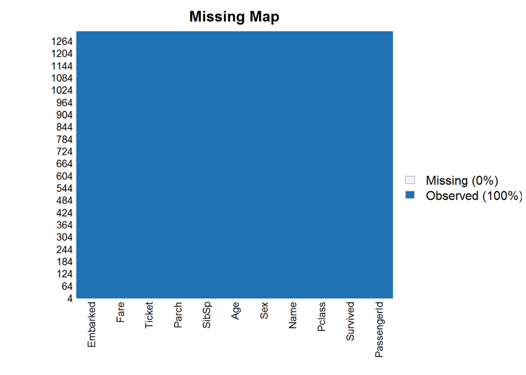

```r
library("Amelia")
missmap(df_concat, main = "Missing Map")
```

**Bingo!! now all the missing values have been cleaned now I’ll split my data into training and test set then use them in visual analysis of the two data set before actual machine learning is done on them as shown below.**

```r
df.train.cleaned <- df_concat[1:891,]
df.test.cleaned <- df_concat[892:1309,]
```

**Next I’ll call `ggplot2` package which plays a crucial part in data visualization as shown below.**

```r
library(ggplot2)
```

**Next I’ll be using both trainig and test set in visualization I’ll begin by creating a table of people who survived and died in my traing set as below.**

```r
xtabs(~Survived, df.train.cleaned)
```

```
## Survived
##   0   1
## 549 342
```

**From the table above 549 people died and 342 survived in the training set.** **I’ll represent the above table using bar plot as shown below.**

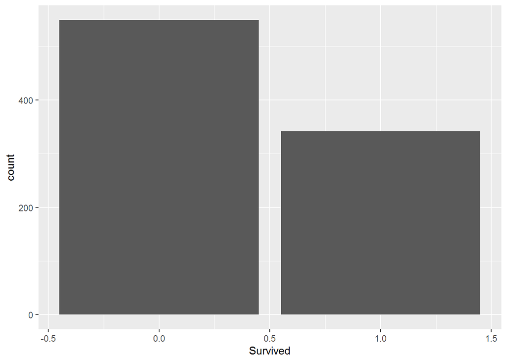

```r
ggplot(df.train.cleaned) + geom_bar(aes(x=Survived))
```

**Next I’ll visualize `Sex` column in the traing set to see the gender that were many in the titanic as shown below.**

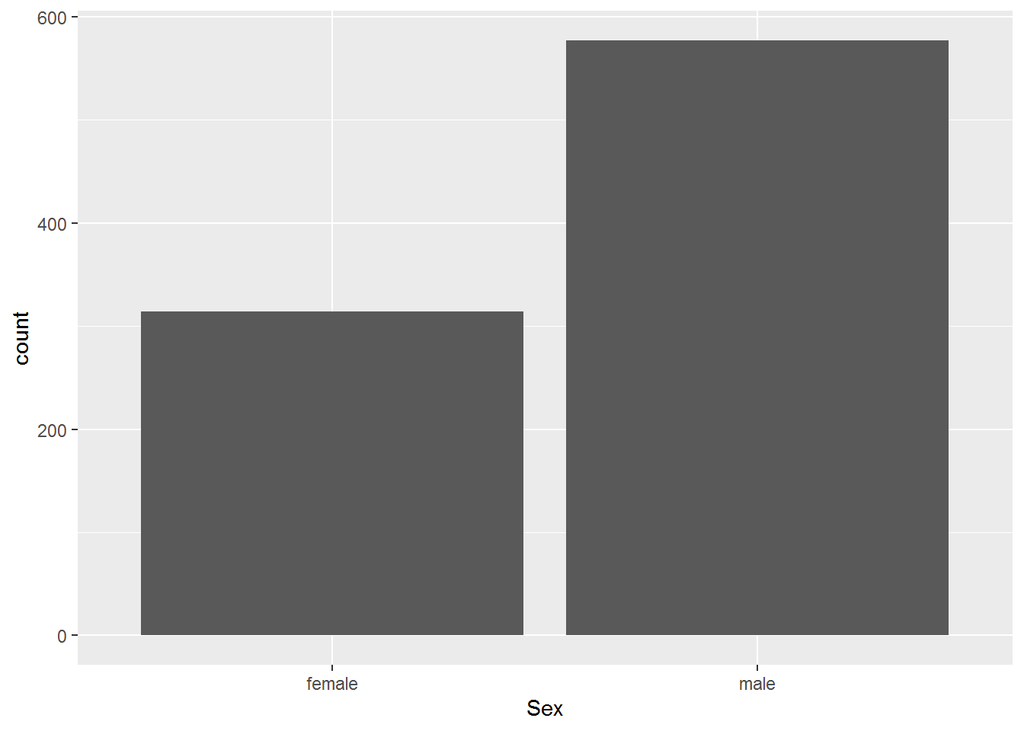

```r
ggplot(df.train.cleaned) + geom_bar(aes(x=Sex))
```

**From above table it is evident that more males were in the titanic compared to females.** **Next I’ll draw a bar plot to see how people were distributed in three classes using the below code.**

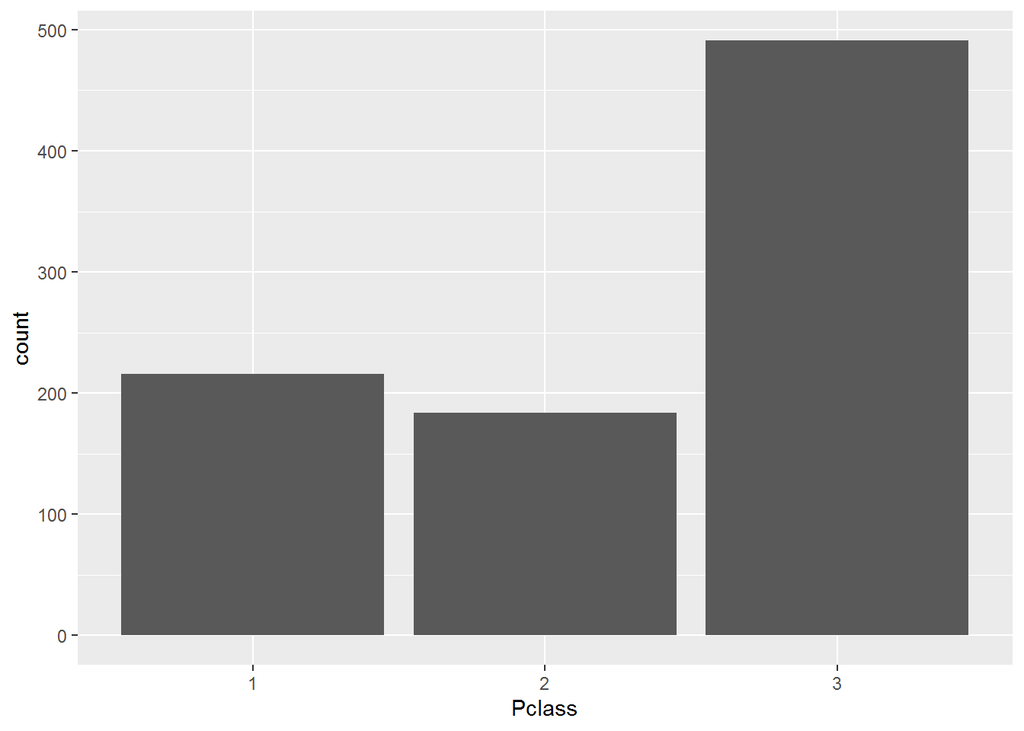

```r
ggplot(df.train.cleaned) + geom_bar(aes(x=Pclass))
```

**From above table there were more people in the third class compared to other classes while second class being least.** **Next I’ll use a histogram to show if `Fare` is normaally distributed and also see its skewness.**

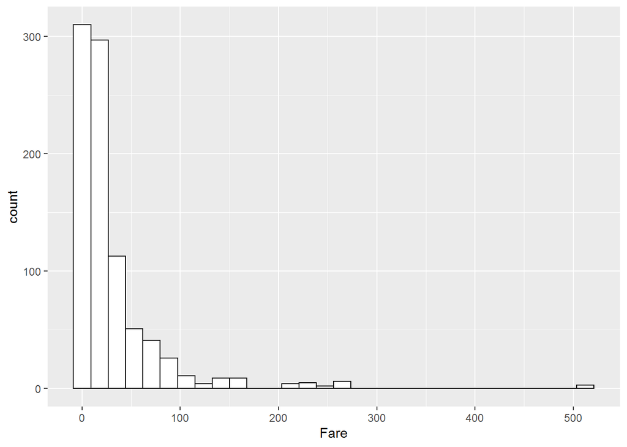

```r
ggplot(df.train.cleaned) + geom_histogram(aes(x=Fare),fill = "white", colour = "black")
```

**From the table above it is evident that `Fare` is right skewed hence the price is not normal distributed.** **Next is to draw a boxplot to see how price is distributed and also capture the outliers.**

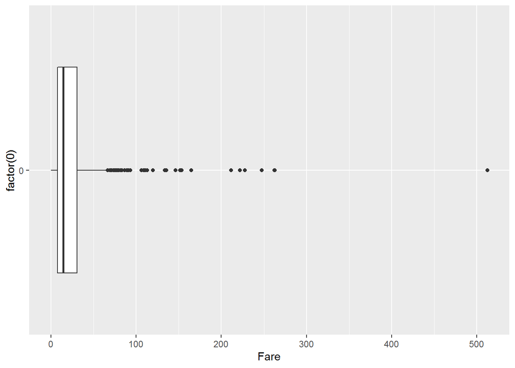

```r
ggplot(df.train.cleaned) + geom_boxplot(aes(x=factor(0),y=Fare)) + coord_flip()
```

**From above boxplot it can be seen that `Fare` is right skewed with even a person paying more than 500.** **Next I’ll draw a histogram to show how `Age` is distributed.**

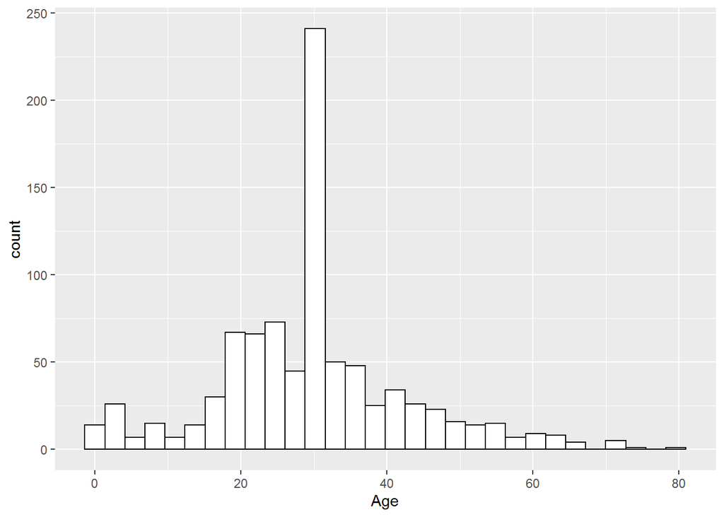

```r
ggplot(df.train.cleaned) + geom_histogram(aes(x=Age),fill = "white", colour = "black")
```

**From above it is evident that `Age` is normally distributed with a mean of roughly 30.** **Next I’ll draw a boxplot for further inference on the `Age`.**

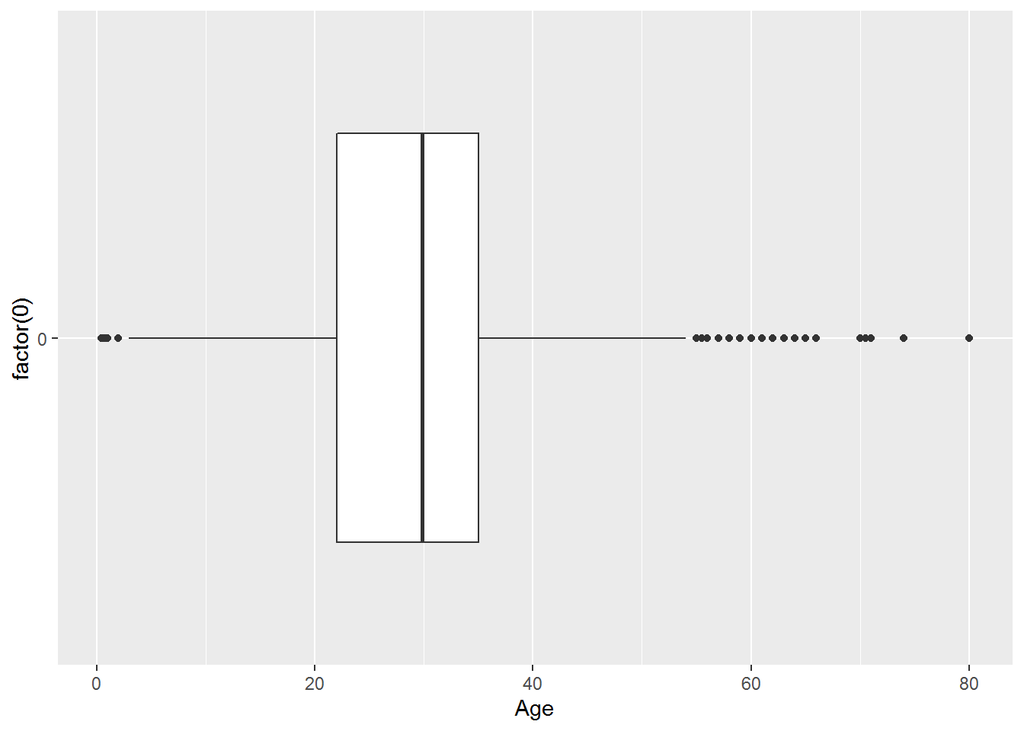

```r
ggplot(df.train.cleaned) + geom_boxplot(aes(x=factor(0),y=Age)) + coord_flip()
```

**From above boxplot it can be seen that `Age` is normally distributed.** **Next I’ll make a table to show how survival count in the `Sex` is distributed.**

```r
xtabs(~Survived+Sex,df.train.cleaned)
```

```
##         Sex
## Survived female male
##        0     81  468
##        1    233  109
```

**From above table it is evident that more males died compared to females while more females survived compared to males.** **Next I’ll draw a bar plot to visualize above table.**

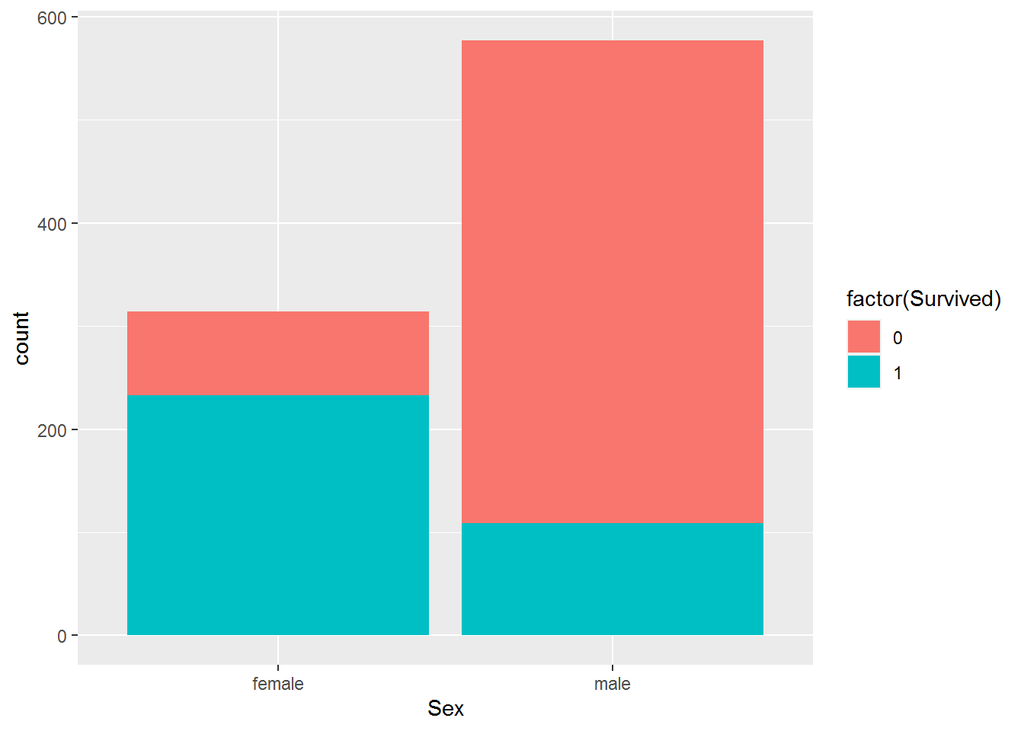

```r
ggplot(df.train.cleaned) + geom_bar(aes(x=Sex, fill=factor(Survived)))
```

**Next I’ll make a table to show the survival rate in the three classes as shown below.**

```r
xtabs(~Survived+Pclass,df.train.cleaned)
```

```
##         Pclass
## Survived   1   2   3
##        0  80  97 372
##        1 136  87 119
```

**From above table more people died in the third class as compared to rest of classes while people who were in the first class survived to compared to the rest of the classes.** **Next I’ll visualize above table using bar plot for visual inference.**

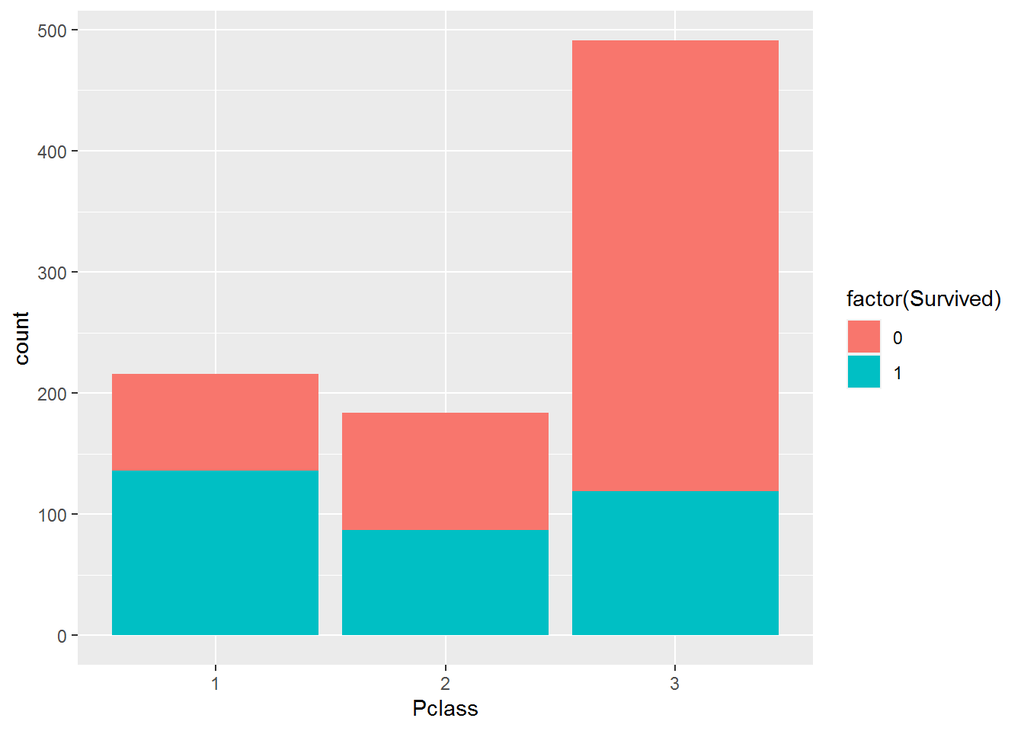

```r
ggplot(df.train.cleaned) + geom_bar(aes(x=Pclass, fill=factor(Survived)) )
```

**Next I’ll make a table to see survival rate from three stations as below.**

```r
xtabs(~Survived+Embarked,df.train.cleaned)
```

```
##         Embarked
## Survived   C   Q   S
##        0  75  47 427
##        1  93  30 219
```

**From the table above it is evident that more people from `Southampton` boarded the titanic and also it is them that died in large number than the rest and also it is them that died most while least death and survival registered by `Queenstown`.** **I’ll visualize the above table using a bar plot for further visual inference.**

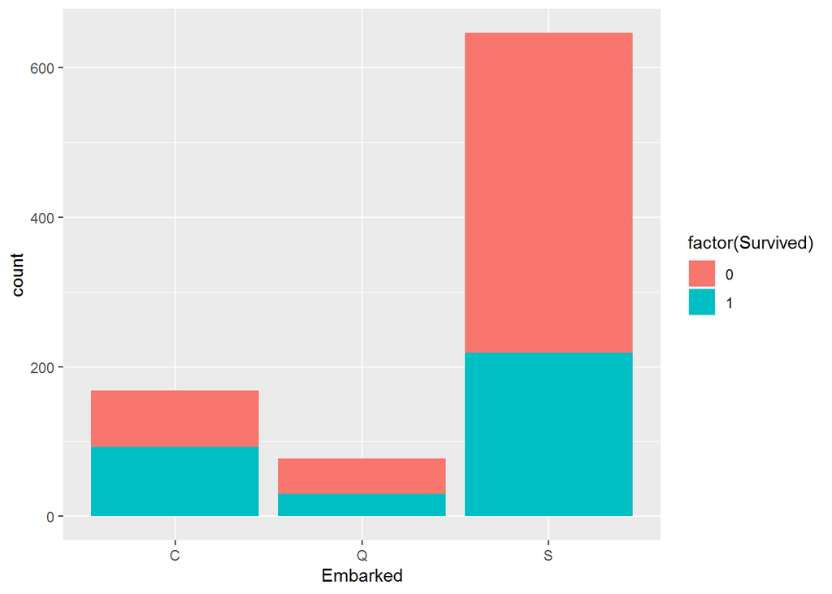

```r
ggplot(df.train.cleaned) + geom_bar(aes(x=Embarked, fill=factor(Survived)) )
```

**Next I’ll draw a boxplot to show how suvival rate for `Age` column .**

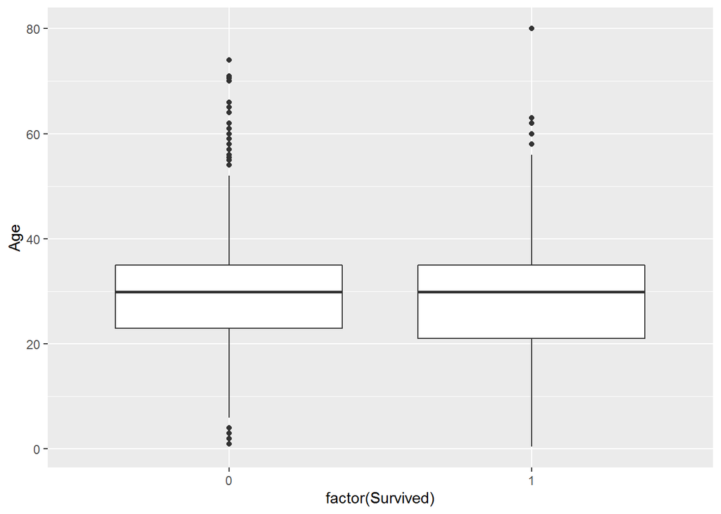

```r
ggplot(df.train.cleaned) + geom_boxplot(aes(x = factor(Survived), y = Age))
```

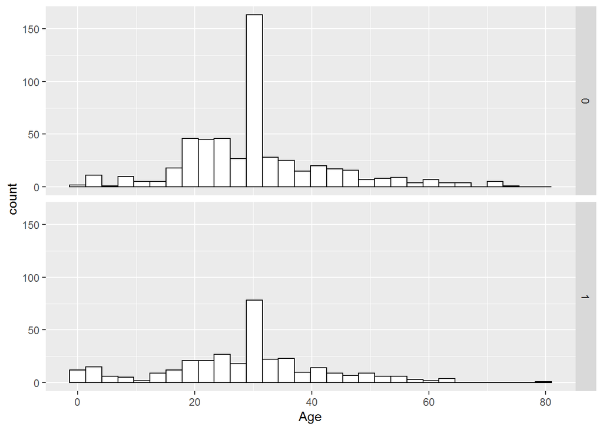

```r
ggplot(df.train.cleaned) + geom_histogram(aes(x = Age),fill = "white", colour = "black") + facet_grid(factor(Survived) ~ .)
```

**Next I’ll draw a boxplot of `Fare` against `Survived` to see if `Fare` played a major role in survival rate.**